## Analysis of NYC Taxi Data

In this section, we try to answer some of the business related questions based on our experience on the data set and the developed models.

```r
filename <- "sampledData100000.csv";
records  <- read.csv(filename);

if (!require(lubridate)) install.packages('lubridate')
library(lubridate)

if (!require(geosphere)) install.packages('geosphere')
library(geosphere)

if (!require(ggplot2)) install.packages('ggplot2')
library(ggplot2)

if (!require(lattice)) install.packages('lattice')
library(lattice)
```

```r
lmData  <- data.frame(taxi=records$hack_license, fare=records$fare_amount, tip=records$tip_amount, tripDuration=records$trip_time_in_secs, pickLat=records$pickup_latitude, pickLon=records$pickup_longitude,
                      dropLat=records$dropoff_latitude, dropLon=records$dropoff_longitude,
                      day=wday(records$pickup_datetime), hour=hour(records$pickup_datetime))

lmData <- lmData[lmData$pickLat < 40.85 & lmData$pickLat > 40.65, ]
lmData <- lmData[lmData$dropLat < 40.85 & lmData$dropLat > 40.65, ]
lmData <- lmData[lmData$pickLon < -73.93 & lmData$pickLon > -74.02, ]
lmData <- lmData[lmData$dropLon < -73.93 & lmData$dropLon > -74.02, ]
lmData <- lmData[lmData$pickLat!=lmData$dropLat & lmData$pickLon!=lmData$dropLon, ]

requestedDay  = floor(runif(1, 1, 7));
requestedHour = floor(runif(1, 0, 23));
```

### 2.c) If you were a taxi owner, how would you maximize your earnings in a day?

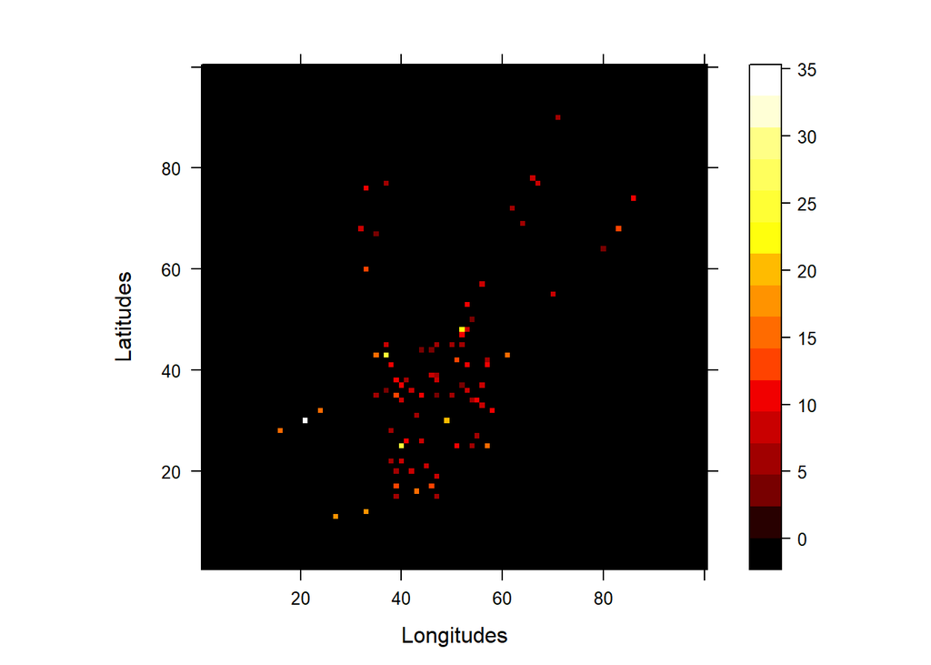

```r
# requestedDay  = floor(runif(1, 1, 7));
# requestedHour = floor(runif(1, 0, 23));

numSamples  <- 10000
maxItter    <- 100
resGPS      <- 100
numDigitGps <- 3

seqPickLat <- seq(40.65, 40.85, length.out = resGPS)
seqPickLon <- seq(-74.02, -73.93, length.out = resGPS)

nycModelFare <- array(0,dim=c(resGPS,resGPS,2))

for (m in 1:100){
  lmDataSampled <- lmData[sample(1:nrow(lmData), numSamples, replace=TRUE),]
  requestedData <- lmDataSampled[lmDataSampled$day==requestedDay & lmDataSampled$hour==requestedHour, ]
  for (n in 1:nrow(requestedData)){
    i <- match(round(requestedData$pickLat[n], digits = numDigitGps), round(seqPickLat, digits = numDigitGps))
    j <- match(round(requestedData$pickLon[n], digits = numDigitGps), round(seqPickLon, digits = numDigitGps))

    nycModelFare[i,j,1] <- nycModelFare[i,j,1] + requestedData$fare[n]
    nycModelFare[i,j,2] <- nycModelFare[i,j,2] + 1;
  }
}

fareHeatMap <- nycModelFare[,,1]/nycModelFare[,,2]
fareHeatMap[is.nan(fareHeatMap)] <- 0

new.palette=colorRampPalette(c("black","red","yellow","white"),space="rgb")
levelplot(fareHeatMap,col.regions=new.palette(20), xlab="Longitudes", ylab="Latitudes")
```

Note: I am still checking how to map the tick labels to Longitudes and Latitudes. The intensity is a measure of the average fare earned for a given day, hour and a location for a trip.

### 2.d) If you were a taxi owner, how would you minimize your work time while retaining the average wages earned by a typical taxi in the dataset?

Here we assume Taxi Driver try to maximize the Tip rather than driving. Using the same way as maximize the fare, here the driver keeps an intensity map of Tip for a given day and hour. The driver should identify the sweet spots from the map and move to that location. To generate the following map, we iterate the algorithm 100 times with different random samples (Bootstrap).

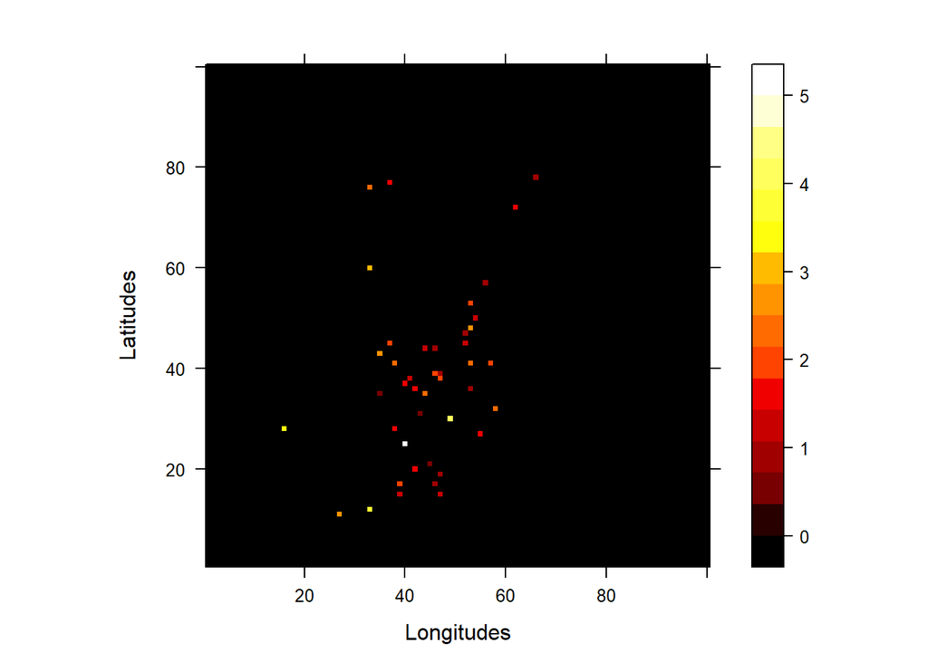

```r
# requestedDay  = floor(runif(1, 1, 7));
# requestedHour = floor(runif(1, 0, 23));

numSamples  <- 10000
maxItter    <- 100
resGPS      <- 100
numDigitGps <- 3

seqPickLat <- seq(40.65, 40.85, length.out = resGPS)
seqPickLon <- seq(-74.02, -73.93, length.out = resGPS)

nycModelTip <- array(0,dim=c(resGPS,resGPS,2))

for (m in 1:100){
  lmDataSampled <- lmData[sample(1:nrow(lmData), numSamples, replace=TRUE),]
  requestedData <- lmDataSampled[lmDataSampled$day==requestedDay & lmDataSampled$hour==requestedHour, ]
  for (n in 1:nrow(requestedData)){
    i <- match(round(requestedData$pickLat[n], digits = numDigitGps), round(seqPickLat, digits = numDigitGps))
    j <- match(round(requestedData$pickLon[n], digits = numDigitGps), round(seqPickLon, digits = numDigitGps))

    nycModelTip[i,j,1] <- nycModelTip[i,j,1] + requestedData$tip[n]
    nycModelTip[i,j,2] <- nycModelTip[i,j,2] + 1;
  }
}

tipHeatMap <- nycModelTip[,,1]/nycModelTip[,,2]
tipHeatMap[is.nan(tipHeatMap)] <- 0

new.palette=colorRampPalette(c("black","red","yellow","white"),space="rgb")
levelplot(tipHeatMap,col.regions=new.palette(20), xlab="Longitudes", ylab="Latitudes")
```

Note: I am still checking how to map the tick labels to Longitudes and Latitudes. The intensity is a measure of the average Tip earned for a given day, hour and a location for a trip.

The Tip has a relationship with the day and the hour. Following intensity map shows what are the best hours for higher Tip. Drivers can work on those hours to get higher Tip.

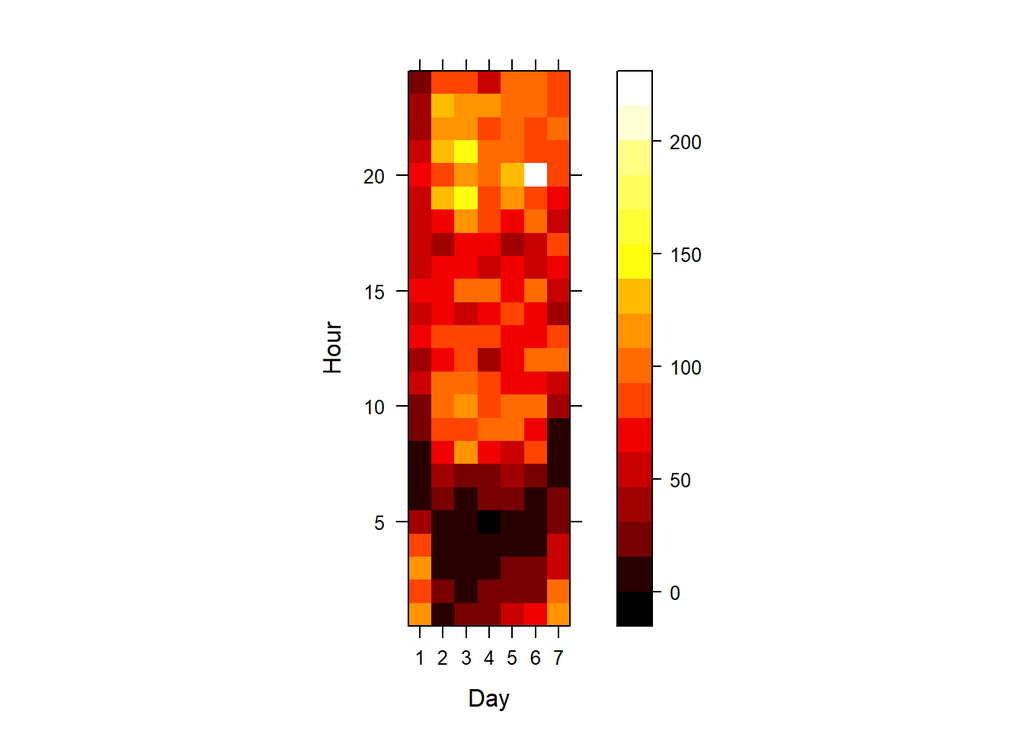

```r
numSamples <- 10000
tipMat <- matrix(0, nrow=7, ncol=24)

lmDataSampled <- lmData[sample(1:nrow(lmData), numSamples, replace=TRUE),]

for (k in 1:numSamples){
  tipMat[lmDataSampled$day[k],lmDataSampled$hour[k]+1] <- tipMat[lmDataSampled$day[k],lmDataSampled$hour[k]+1] + lmDataSampled$tip[k]
}

new.palette=colorRampPalette(c("black","red","yellow","white"),space="rgb")
levelplot(tipMat,col.regions=new.palette(20), xlab="Day", ylab="Hour")
```

We identified the Tip has a relationship with the speed. People like to travel reasonably fast. Drivers drive 40 km/h can earn higher Tip.

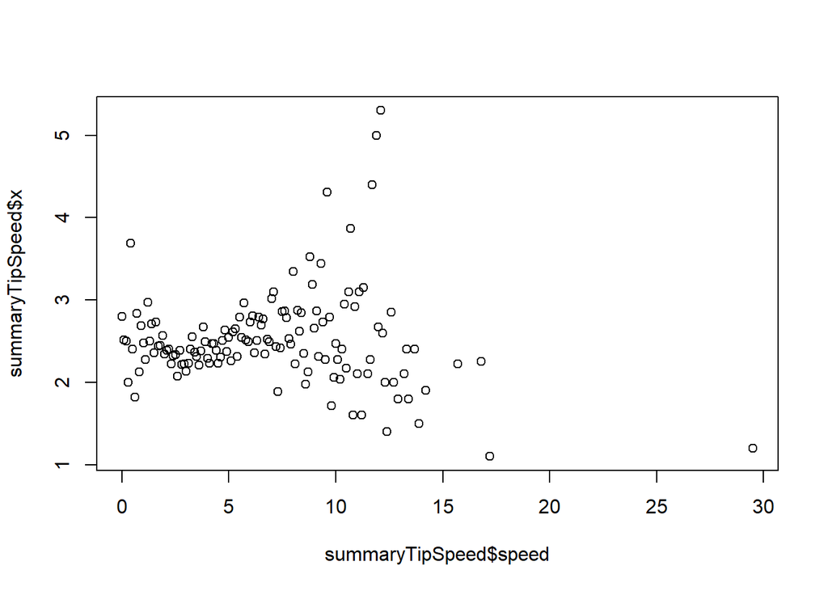

```r
numSamples <- 10000

lmDataSampled <- lmData[sample(1:nrow(lmData), numSamples, replace=TRUE),]
requestedData <- lmDataSampled[lmDataSampled$tip>median(lmDataSampled$tip), ]

x1 <- c(requestedData$pickLat)
y1 <- c(requestedData$pickLon)
x2 <- c(requestedData$dropLat)
y2 <- c(requestedData$dropLon)
distMat <- distm (cbind(y1,x1), cbind(y2,x2), fun = distHaversine);
speed <- diag(distMat)/requestedData$tripDuration

tipSpeed <- data.frame(tip=requestedData$tip, speed=round(speed, digits = 1))
summaryTipSpeed <- aggregate(tipSpeed$tip, by=list(speed=tipSpeed$speed), FUN=mean)
plot(summaryTipSpeed$speed, summaryTipSpeed$x)
```

Note that higher Tip at lower speed is due to a lot of small tips. In the distribution of the Tip, most of the Tips are $1 which is not the focus. The distribution of the Tip is given below.

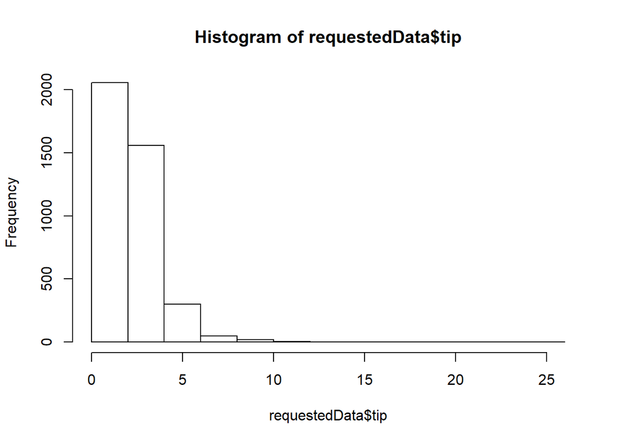

```r
hist(requestedData$tip)
```

### 2.e) If you run a taxi company with 10 taxis, how would you maximize your earnings?

Here we propose 2 things.

1 - Identify the 10 clusters having busiest pickup locations. The Taxis can be operated on those clusters closer to the cluster center.

```r
requestedDay
```

```
## [1] 4
```

```r
requestedHour
```

```
## [1] 1
```

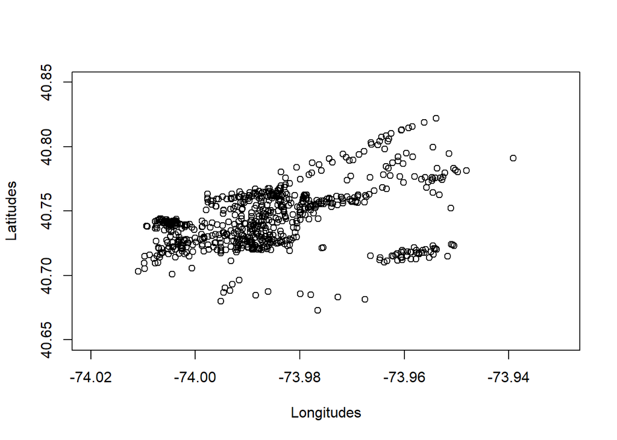

```r
maxItter <- 100
numSamples <- 10000

plot(c(-74.02,-73.93), c(40.65,40.85), col="white", xlab="Longitudes", ylab="Latitudes")
bigCluster <- data.frame(x=-73.95,y=40.75);
for (i in c(1:maxItter)){
  lmDataSampled <- lmData[sample(1:nrow(lmData), numSamples, replace=TRUE),]
  requestedData <- lmDataSampled[lmDataSampled$day==requestedDay & lmDataSampled$hour==requestedHour, ]
  x <- c(requestedData$pickLon)
  y <- c(requestedData$pickLat)
  gpsCordinates <- cbind(x,y)
  kc1 <- kmeans(gpsCordinates, 10)
  points(kc1$centers,cex=1)
  bigCluster <- rbind(bigCluster,kc1$centers)
}
```

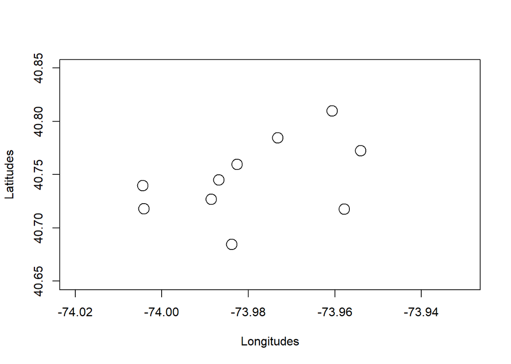

```r
gpsCordinates <- cbind(bigCluster)
kc2 <- kmeans(gpsCordinates, 10)
plot(c(-74.02,-73.93), c(40.65,40.85), col="white", xlab="Longitudes", ylab="Latitudes")
points(kc2$centers,cex=2)
```

```r
kc2$centers
```

```
##            x        y
## 1  -73.97322 40.78479
## 2  -73.95407 40.77240
## 3  -73.98264 40.75968
## 4  -73.98384 40.68453
## 5  -73.98682 40.74496
## 6  -74.00418 40.71801
## 7  -73.95789 40.71764
## 8  -73.96063 40.81002
## 9  -73.98857 40.72691
## 10 -74.00447 40.73979
```

2 - Identify the sweet-locations of the given day and hour from the fare intensity map. Then all the taxies can be directed to those sweet locations.

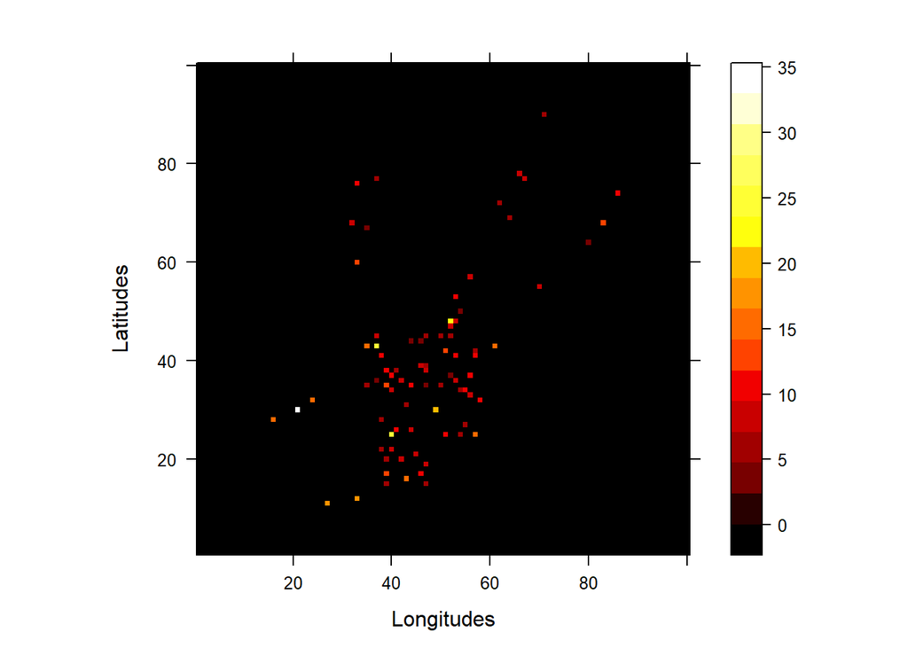

```r
numSamples  <- 10000
maxItter    <- 100
resGPS      <- 100
numDigitGps <- 3

seqPickLat <- seq(40.65, 40.85, length.out = resGPS)
seqPickLon <- seq(-74.02, -73.93, length.out = resGPS)

nycModelFare <- array(0,dim=c(resGPS,resGPS,2))

for (m in 1:100){
  lmDataSampled <- lmData[sample(1:nrow(lmData), numSamples, replace=TRUE),]
  requestedData <- lmDataSampled[lmDataSampled$day==requestedDay & lmDataSampled$hour==requestedHour, ]
  for (n in 1:nrow(requestedData)){
    i <- match(round(requestedData$pickLat[n], digits = numDigitGps), round(seqPickLat, digits = numDigitGps))
    j <- match(round(requestedData$pickLon[n], digits = numDigitGps), round(seqPickLon, digits = numDigitGps))

    nycModelFare[i,j,1] <- nycModelFare[i,j,1] + requestedData$fare[n]
    nycModelFare[i,j,2] <- nycModelFare[i,j,2] + 1;
  }
}

fareHeatMap <- nycModelFare[,,1]/nycModelFare[,,2]
fareHeatMap[is.nan(fareHeatMap)] <- 0

new.palette=colorRampPalette(c("black","red","yellow","white"),space="rgb")
levelplot(fareHeatMap,col.regions=new.palette(20), xlab="Longitudes", ylab="Latitudes")
```

Note: I am still checking how to map the tick labels to Longitudes and Latitudes. The intensity is a measure of the average fare earned for a given day, hour and a location for a trip.

[figure not shown]